# SCEM Summative Assessment Section A

## Introduction

This R Markdown document is my completion of Section A of the summative assessment for the Statistical Computing and Empirical Methods module, EMATM0061.

### A.1

First, we read in the finance data file and print the number of rows and columns.

```r
# Reading csv file into R data frame
finance_data_original <- read.csv("/Users/maxkirwan/Desktop/Uni/Data Science MSc/SCEM/jy18214_EMATM0061_summative_assessment/jy18214_EMATM0061_A/finance_data_EMATM0061.csv")

print(nrow(finance_data_original))
```

```
## [1] 1051
```

```r
print(ncol(finance_data_original))
```

```
## [1] 30
```

This finance data frame has 1051 rows and 30 columns.

### A.2

We shall now subset the original data frame to include only the columns of interest.

```r
# Selecting columns of interest
finance_data <- finance_data_original %>% dplyr::select(state_year_code,
                                    education_expenditure = Details.Education.Education.Total,
                                    health_expenditure = Details.Health.Health.Total.Expenditure,
                                    transport_expenditure = Details.Transportation.Highways.Highways.Total.Expenditure,
                                    totals_revenue = Totals.Revenue,
                                    totals_expenditure = Totals.Expenditure)
head(finance_data,5)[1:3]
```

```
##   state_year_code education_expenditure health_expenditure
## 1   ALABAMA__1992               3570524                 NA
## 2   ALABAMA__1993               3663465                 NA
## 3   ALABAMA__1994               3969277             487044
## 4   ALABAMA__1995               4400912             491648
## 5   ALABAMA__1996               4872259             514380
```

### A.3

Next, we create a new column which is a calculation of total savings.

```r
# Creating new totals_savings column
finance_data <- finance_data %>% mutate(totals_savings=totals_revenue-totals_expenditure)
head(finance_data,3)[c(1,5,6,7)]
```

```
##   state_year_code totals_revenue totals_expenditure totals_savings
## 1   ALABAMA__1992       10536166            9650515         885651
## 2   ALABAMA__1993       11389335           10242374        1146961
## 3   ALABAMA__1994       11599362           10815221         784141
```

### A.4

Next, we shall reformat the state and year columns as required.

```r
# Formatting state and year columns
finance_data <- finance_data %>% separate(col=state_year_code,into=c("state","year"),sep="__",convert=1)
finance_data <- finance_data %>% mutate(state=str_to_title(finance_data$state))
head(finance_data,3)[c(1,2,6,7,8)]
```

```
##     state year totals_revenue totals_expenditure totals_savings
## 1 Alabama 1992       10536166            9650515         885651
## 2 Alabama 1993       11389335           10242374        1146961
## 3 Alabama 1994       11599362           10815221         784141
```

### A.5

We shall now generate a plot which displays the total revenue by year for Louisiana, Montana, Mississippi and Kentucky.

```r
# Subsetting our df to include required states only
finance_data_subset <- finance_data %>% subset(state %in% c("Louisiana","Montana","Mississippi","Kentucky"))
```

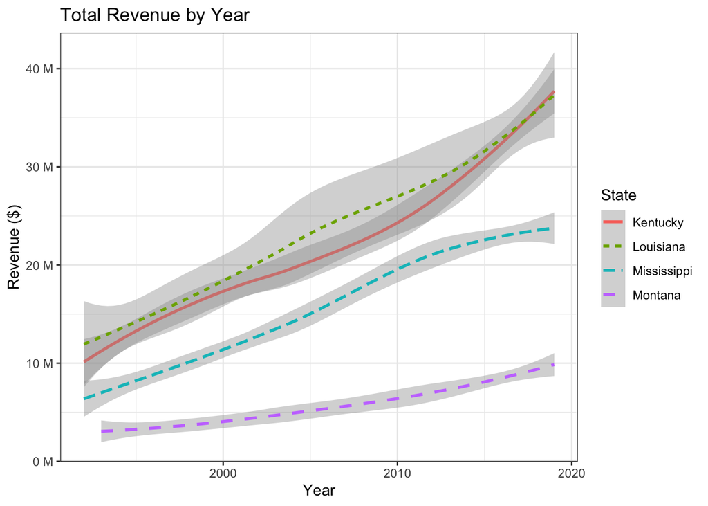

```r
# Generating a plot to display total revenue by year for the four states
library(scales) # needed to scale y axis to millions
ggplot(finance_data_subset,aes(x=year,y=totals_revenue,colour=state,linetype=state)) +
  geom_smooth(method='loess',formula='y ~ x') +
  scale_y_continuous(labels=unit_format(unit="M", scale=1e-6)) +
  labs(title="Total Revenue by Year",x="Year",y="Revenue ($)",colour="State",linetype="State") +
  theme_bw()
```

### A.6

Next, we shall create a function to determine the decade, and use this to add a new column to the data frame corresponding to the decade.

```r
# The function get_decade takes a year as input and outputs the decade of that year
get_decade <- function(year){
  if(!(year%%1 == 0)){return("Error: input not an integer value")}
  years_past_decade <- year%%10
  return(year-years_past_decade)
}

# Adding new decade column to finance_data
finance_data <- finance_data %>% mutate(decade=map_dbl(.x=year,.f=~get_decade(.x)))

# Which 3 states had the highest average savings over the decade starting in 2000?
avg_savings_2000 <- finance_data %>%
  subset(decade==2000) %>%
  group_by(state) %>%
  summarise(average_savings=mean(totals_savings,na.rm=1)) %>%
  arrange(desc(average_savings))
head(avg_savings_2000,3)
```

```
## # A tibble: 3 × 2
##   state      average_savings
##   <chr>                <dbl>
## 1 Texas             4103352.
## 2 Ohio              3025980
## 3 California        2510483.
```

Texas, Ohio and California had the highest average savings over the decade started in 2000.

### A.7

We shall now generate a new data frame which displays some summary statistics for the state of Alaska.

```r
# Creating a summary data frame showing mean and median expenditures per decade in Alaska
alaska_summary <- finance_data %>%
  subset(state=="Alaska") %>%
  group_by(decade) %>%
  summarise(ed_mn=mean(education_expenditure,na.rm=1),ed_md=median(education_expenditure,na.rm=1),he_mn=mean(health_expenditure,na.rm=1),he_md=median(health_expenditure,na.rm=1),tr_mn=mean(transport_expenditure,na.rm=1),tr_md=median(transport_expenditure,na.rm=1))
alaska_summary
```

```
## # A tibble: 3 × 7
##   decade    ed_mn    ed_md   he_mn   he_md    tr_mn    tr_md
##    <dbl>    <dbl>    <dbl>   <dbl>   <dbl>    <dbl>    <dbl>
## 1   1990 1246426. 1246864. 162785. 164546.  582137.  582710.
## 2   2000 1546233. 1566815  152003. 160168   723347.  687407
## 3   2010 2642603. 2595207  274688  278394  1210822. 1271514
```

### A.8

Finally, we shall create a function and use it to create a new data frame, containing values related to the state of Idaho, where any missing values are replaced with their corresponding median value.

```r
# The function impute_by_median replaces any NAs from a numerical vector with the median of the vector
impute_by_median <- function(x){
  median <- median(x,na.rm=1)
  impute <- function(z){
    if(is.na(z)){return(median)}
    else{return(z)}
  }
  return(map_dbl(.x=x,.f=~impute(.x)))
}

# Subsetting the finance df to include only data relating to Idaho in the decade 2000
idaho_2000 <- finance_data %>%
  subset(state=="Idaho" & decade==2000) %>%
  dplyr::select(-state,-decade)

# Imputing by median on all columns in idaho_2000 df
idaho_2000_imputed <- idaho_2000 %>% mutate(education_expenditure=impute_by_median(education_expenditure),
                      health_expenditure=impute_by_median(health_expenditure),
                      transport_expenditure=impute_by_median(transport_expenditure),
                      totals_revenue=impute_by_median(totals_revenue),
                      totals_expenditure=impute_by_median(totals_expenditure),
                      totals_savings=impute_by_median(totals_savings))

idaho_2000_imputed[c(1,2,3,7)]
```

```
##     year education_expenditure health_expenditure totals_savings
## 240 2000               1663980            98510.0        1083732
## 241 2001               1768837           103705.0         334438
## 242 2002               1768837           109896.5        -746375
## 243 2003               1886421           116088.0         709085
## 244 2004               1768837           131165.0        1349740
```